# Python

[figure not shown]

## Chapter 1

### Introduction

##### Definitions

Program: A set of instructions that a computer follows to perform a task.

Commonly referred to as Software.

Programmer: A person who can design, create, and test computer programs.

Also known as a Software Developer.

### Hardware and Software

##### Definitions

Hardware: The physical devices that make up a computer.

Central Processing Unit (CPU): The part of the computer that actually runs programs.

Microprocessors: CPU's located on small chips.

Main Memory (RAM, or Random Access Memory): Where the computer stores a program and its data while it is running.

The CPU is able to quickly access data in RAM, and the contents are volatile (erased when the computer is turned off.

Secondary Storage: Non-volatile storage that can hold data for a long time.

Programs stored in secondary storage are loaded into main memory when needed.

Some types of secondary storage are disk drives, solid state drives, flash memory, and optical devices.

Input: Data the computer collects from people and other devices.

Input Device: A component that collects data.

Some examples of input devices are keyboards, a mouse, a scanner, a camera, and disc drives.

Output: Data produced by the computer for other people or devices.

Some examples include text, image, audio, or bit stream.

Output Device: Formats and presents output.

Some examples are a video display, a printer, disk drives, and cd recorders.

Application Software: Programs that make a computer useful for every day tasks.

Some examples are word processors, email software, games, and web browsers.

System Software: Programs that control and manage basic operations of a computer.

Operating System: Controls the operations of hardware components.

Utility Program: Performs specific tasks to enhance computer operation or to safeguard data.

Software Development Tools: Used to create, modify, and test software programs.

### How Computers Store Data

##### Definitions

Byte: Just enough memory to store a letter or small number. A byte is divided into eight bits.

Bytes range from 0 to 255.

Bit: An electrical component that can hold positive or negative charge. Bits store 1's and 0's respectively.

Nibble: Four bits.

Binary: Simply put, binary means you are working in base 2.

ASCII: Defines codes for 128 characters.

Unicode: An extension upon ASCII.

Negative Numbers: Stored using two's complement.

Real Numbers: Stored using floating-point notation.

Digital: Digital describes any device that stores data as binary numbers.

Digital images are composed of pixels.

Digital music is composed of samples.

### How a Program Works

##### Definitions

Fetch: When the CPU reads the next instruction from memory into the CPU.

Decode: When the CPU decodes a fetched instruction to determine which operation to perform.

Execute: When the CPU performs the decoded operation.

Assembly Language: Uses short words (mnemonics) for instructions instead of binary numbers.

Assembler: Translates assembly language to machine language for execution by the CPU.

Low-level Language: Close in nature to machine language.

An example would be Assembly.

High-level Language: Allows simple creation of powerful and complex programs.

Key Words: Predefined words used to write a program in a high-level language. Each key word has semantic meaning.

Operators: Operators perform operations on data.

An example of operators would be math operators used to perform arithmetic.

Operand: Values that surround operators.

Syntax: A set of rules to be followed when writing a program.

Statement: An individual instruction used in high-level languages.

Compiler: Translates a high-level language program into a seperate machine language program.

Interpreter: Translates and executes instructions in a high-level language program.

Python, as an example, interprets one instruction at a time and does not create a seperate machine language program.

Source Code: Statements written by a programmer.

Syntax Error: Prevents code from being translated.

### Program Development

##### Definitions

Reductionism: Breaking big problems down into smaller problems.

Program Development: The progression from analysis, to design, to implementation.

Analysis: Understand the problem.

Design: Organize the solution.

Implementation: Get the solution running.

Deliverable: An item that indicates progress was made during analysis, design, or implementation.

Analysis Deliverable: A document that lists the variable names and a sample problem for your program.

Design Deliverable: An algorithm that outlines a solution.

Implementation Deliverable: An executable program.

Variable: Stores data. Each variable has a name, value, and data type.

Assignment Statement: Used to create a variable and make it reference data.

Garbage Collection: Removal of values that are no longer referenced by variables.

IPO: Input, Processing, Output.

Pseudocode: Abstract code used in your program development to work out a problem (no syntax).

##### Examples

Problem: Using this grade assessment, compute a course grade as a weighted average for any combination of two tests and one final exam.

Grade Assessment Item Percentage of Grade

Test 1 (0.0 to 100.0) 25%

Test 2 (0.0 to 100.0) 25%

Test 3 (0.0 to 100.0) 50%

Analysis:  
Variables

testOne

testTwo

testThree

weightedAverage

Example

testOne = 67

testTwo = 73

testThree = 93

Design

get testOne as float

get testTwo as float

get testThree as float

process weightedAverage

(testOne*.25)+(testTwo*.25)+(testThree*.50) =81.5

display weightedAverage

Implementation

```python
#Input
testOne = float(input("Please provide a grade for test 1:"))
testTwo = float(input("Please provide a grade for test 2:"))
testThree = float(input("Please provide a grade for test 3:"))

weightedAverage = 0.0

#Process
weightedAverage = (testOne * .25)+(testTwo * .25)+(testThree * .50)

#Output
print("The weighted average is:",weightedAverage)
```

```
Please provide a grade for test 1:67
Please provide a grade for test 2:73
Please provide a grade for test 3:93
The weighted average is: 81.5
```

## Chapter 2

### Designing a Program

##### Definitions

Algorithm: A set of well defined logical steps that must be taken to perform a task.

Flowchart: A diagram that graphically depicts the steps in a program.

[figure not shown]

### Displaying Output with the Print Function

##### Definitions

Function: A piece of pre-written code that performs an operation.

Print Function: Displays output on the screen.

Argument: Data that is given to a function.

Numeric Literal: A number written in a program.

String: A sequence of characters that is used as data.

Integer: A number without a decimal.

Float: A number with a decimal.

Boolean: A True or False value.

Primitives: The default data types offered by a high-level language.

##### Examples

```python
argument = "Hello World!"
print(Argument)
```

[output not shown]

```python
variable = "variable."
print("This is how you print a",variable)
```

```
This is how you print a variable.
```

```python
#The \ character is an escape character in python
print("This is a \
break statement.")
```

```
This is a break statement.
```

```python
#This is how you set the delimiter
print('a','b','c',sep='')
print('a','b','c',sep=' ')
print('a','b','c',sep=',')
```

```
abc
a b c
a,b,c
```

```python
#This is how you use tab
print("This is a \t tab.")
```

```
This is a 	 tab.
```

```python
#This is how you return
print("This is a \nreturn.")
```

```
This is a
return.
```

```python
#This is how you concatenate
print("This is how "+"you concatenate.")
```

```
This is how you concatenate.
```

```python
#This is how you import an external library
import numpy as np

#This is an example of formatting
pi = np.pi
print(pi)
print(format(pi,'0.2f'))
print(format(1000,','))
print("Art: %5d, Price per Unit: %8.2f" % (453, 59.058))
```

```
3.141592653589793
3.14
1,000
Art:   453, Price per Unit:    59.06
```

### Comments

##### Definitions

Comments: Notes that explain the functionality of your program.

##### Examples

#This is a single line comment.

### Calculations

##### Definitions

Floating Point Division: Returns a float.

Integer Division: Returns an Int.

Exponentiation: Raises a number to a power.

Modulus: Returns the remainder.

##### Examples

```python
#Floating Point Division
3/2
```

```
1.5
```

```python
#Integer Division
3//2
```

```
1
```

```python
#Exponentiation
13**2
```

```
169
```

```python
#Modulus
day = 24
hours = 127
print(hours/day)
print(hours % day)
print(hours,"hours is:",hours//day,"Days and",hours%day,"hours.")
```

```
5.291666666666667
7
127 hours is: 5 Days and 7 hours.
```

## Chapter 3

### The if Statement

##### Definitions

Control Structure: A logical design that controls the order in which a set of statements executes.

Sequence Structure: A set of statements that execute in the order in which they appear.

Decision Structure: Specific action(s) performed only if a condition exists.

Single Alternative Decision Structure: Provides only one alternative path of execution.

Boolean Expression: Expression is tested by if statement to determine if it is true.

Relational Operator: Determines whether a specific relationship exists between two values.

##### Examples

```python
from random import randint

number = int(input("Pick a number between 1 and 10:"))
randomNumber = randint(1,10)

if number == randomNumber:
    print("The number was ",randomNumber," and your \
    number was ",number,". Good guess!",sep='')

print("The number was: ",randomNumber)
```

```
Pick a number between 1 and 10:5
The number was:  4
```

### The if-else Statement

##### Definitions

Dual Alternative Decision Structure: Two possible paths of execution.

##### Examples

```python
from random import randint

number = int(input("Pick a number between 1 and 10:"))
randomNumber = randint(1,10)

if number == randomNumber:
    print("The number was ",randomNumber," and your \
    number was ",number,". Good guess!",sep='')
else:
    print("The number was: ",randomNumber)
```

```
Pick a number between 1 and 10:7
The number was:  1
```

### The if-elif-else Statement

##### Examples

```python
#Ask for the mass of an unladen swallow.
#If the mass is below 1, output an error message.
#If the mass is above 100, state that it will not fly.
#Else, print the mass.

mass = int(input("What is the mass of an unladen swallow?\n"))
if mass < 1:
    print("Error, the mass is below 1.")
elif mass > 100:
    print("The swallow will not fly.")
else:
    print(mass)
```

```
What is the mass of an unladen swallow?
50
50
```

### String Comparison

Strings can be compared using the == and != operators.

String comparisons are case sensitive.

Strings can be compared using greater, less, greater or equal, and less or equal.

Strings are compared character based on ASCII values.

Strings have a length property.

Strings are immutable.

##### Examples

```python
stringOne = input("Please enter string one: ")
stringTwo = input("Please enter string two: ")

if stringOne != stringTwo:
    print(stringOne," does not equal ",stringTwo,".",sep='')
else:
    for i in range(len(stringOne)):
        if stringOne[i] != stringTwo[i]:
            print(stringOne," does not\
            equal ",stringTwo,".",sep='')
    else:
        print(stringOne," equals ",stringTwo,".",sep='')
```

```
Please enter string one: string1
Please enter string two: string2
string1 does not equal string2.
```

```python
#Strings can be multiplied
string = "ack "*3
print("heart attack",string,"you oughta know by now!")
```

```
heart attack ack ack ack  you oughta know by now!
```

```python
#ord() returns the ASCII code of a character
character = 'b'
print(ord(character))
```

```
98
```

```python
#chr() returns character represented by ASCII number
print(chr(97))
```

```
a
```

```python
#max() returns highest ASCII value
print(max("SNOOZE"))
```

```
Z
```

```python
#min() returns lowest ASCII value
print(min("abc"))
```

```
a
```

```python
#capitalize() will return string with first letter capitalized
string = "string"
print(string.capitalize())
```

```
String
```

```python
#upper() will return string in uppercase
string = "string"
print(string.upper())
```

```
STRING
```

```python
#lower() will return the string in lowercase
string = "STRING"
print(string.lower())
```

```
string
```

```python
#title() will return the string with all words first
#characters capitalized
sentence = "the sentence"
print(sentence.title())
```

```
The Sentence
```

```python
#Slice gives the character at a given index
string = "Hello World"
print(string[0])
```

```
H
```

```python
#Range Slice gives the characters in a given range
string = "Hello World"
print(string[0:5])
```

```
Hello
```

```python
#Membership returns true if a character exists in a given string
string = "I am Groot!"
print("Groot" in string)
```

```
True
```

```python
#Not Membership returns true if a character does not exist in a given string
string = "I am Groot!"
print("Groot" not in string)
```

```
False
```

## Chapter 4

### Repetition Structures

##### Definitions

Repetition Structure: Makes a computer repeat included code as necessary.

Includes condition-controlled loops and count-controlled loops.

Iteration: One execution of the body of a loop.

While Loop: A pretest loop. A while loop will test a condition BEFORE performing an iteration.

Count Controlled loop (For-Loop): Iterates a specific number of times.

Target Variable: The variable which is the target of the assignment at the beginning of each iteration.

Infinite Loop: A loop that does not have a way of stopping.

Accumulator: A variable used in a loop to keep track of a value being incremented or decremented.

Counter: A variable used in a loop to count the number of times something happens.

Range: Range returns an iterable object, or in other words, a sequence of values that can be iterated over.

One Argument: Used as an ending limit.

Two Arguments: Provides a starting value and an ending limit.

Three Arguments: Provides an additional step value to iterate by.

Augmented Assignment Operators: A special set of operators that provide a shorthand for certain assignment statements.

Sentinel: A special value that marks the end of a sequence of items.

Input Validation: Inspecting input before it is processed by the program.

Nested Loop: A loop that is contained inside another loop.

CSV: Comma Seperated Value.

Delimited: Delimiter can be something other than a comma.

Fixed Width: Set column amount. ex. 5, 10: 00001 NEXTFIELD

##### Examples

```python
primes = [2,3,5,7]
```

```python
#While loop
count = 0
while count < len(primes):
    print (primes[count])
    count += 1  # This is the same as count = count + 1
```

```
2
3
5
7
```

```python
#Break statements

# Prints out first three primes.
count = 0
while True:
    print(primes[count])
    count += 1
    if count >= 3:
        break
```

```
2
3
5
```

```python
# For loop, prints out only odd primes
for x in range(len(primes)):
    # Check if x is even
    if primes[x] % 2 == 0:
        continue #Continue skips over a condition if it is true
    print(primes[x])
```

```
3
5
7
```

```python
#While Loop with Else

# Prints out four primes
count=0
while(count<4):
    print(primes[count])
    count +=1
else:
    print("count value reached %d" %(count))
```

```
2
3
5
7
count value reached 4
```

```python
#For Loop with break
for i in range(1,len(primes)):
    if(i%7==0):
        break
    print(primes[i])
else:
    print("Array element",primes[i]+1,"is not printed. \n\
For loop is terminated because of break but not due to fail in condition.")
```

```
3
5
7
Array element 8 is not printed.
For loop is terminated because of break but not due to fail in condition.
```

```python
#Range with three conditions
for x in range(0,45,5):
    print(x)
```

```
0
5
10
15
20
25
30
35
40
```

```python
#Decrement in range
for x in range(3,0,-1):
    print(x)
```

```
3
2
1
```

```python
#User prompt in while loop
continueOn = True
summation = 0
while continueOn == True:
    numberOne = float(input("Please enter number 1: "))
    numberTwo = float(input("Please enter number 2: "))
    summation = numberOne + numberTwo
    print("The sum is: ",summation)
    userFlag = input("Would you like to keep going? yes, or no.")
    if userFlag.lower() == "yes":
        continueOn = True
    elif userFlag.lower() == "no":
        continueOn = False
    else:
        print("Error, please enter yes or no.")
```

```
Please enter number 1: 1
Please enter number 2: 1
The sum is:  2.0
Would you like to keep going? yes, or no.no
```

```python
#Augmented assignment
summation = 0
for i in range(10):
    summation +=1
print(summation)
```

```
10
```

```python
#Augmented assignment
summation = 10
for i in range(10):
    summation -=1
print(summation)
```

```
0
```

```python
#Nested loop
#Translate a square in R^2 centered at the origin one unit in x and y direction.
x = [0,0,1,1]
y = [0,1,1,0]
matrix = [x,y]
print(matrix)
for x in range(2):
    for y in range(4):
        matrix[x][y] += 1
print(matrix)
```

```
[[0, 0, 1, 1], [0, 1, 1, 0]]
[[1, 1, 2, 2], [1, 2, 2, 1]]
```

## Chapter 5

### Functions

##### Definitions

Function: A group of statements within a program that perform as a specific task.

Modularized Program: A program wherein each task within the program is in its own function.

Modularized programs provide many benefits.

Simpler code.

Code reuse.

Better testing and debugging.

Faster development.

Easier facilitation of teamwork.

Built-in Function: A function provided primitively by the programming language.

Function Lifecycle: The steps a function takes when called.

The function is called.

The function executes its block of code.

The function returns any data necessary for the part of the program that called it to execute.

The program continues.

Encapsulation: An object oriented programming concept that binds together the data and functions that manipulate the data.

Void Function: Executes the statements it contains then terminates.

Value-returning Function: Executes the statements it contains, and then it returns a value back to the statement that called it.

Function Definition: Specifies what the function does.

Function Header: First line of a function. Includes keyword "def" and function name, followed by parentheses and colon.

Block: A set of statements that belong together as a group. Or, the statements included in a function.

Main Function: This function is called when the program starts.

Argument: A piece of data that is sent into a function.

Default Argument: Sets the value in a function call in the case that a caller does not specify it.

Top-down Design: A technique for breaking algorithms into functions.

Hierarchy Chart: Depicts the relationship between functions.

Local Variable: A variable that is assigned to a value inside a function.

Scope: The part of a program in which a variable may be accessed.

Parameter Variable: A variable that is assigned the value of an argument when the function is called.

The scope of a parameter is within the function in which it is being used.

Global Variable: Created by an assignment statement written outside all of your functions.

Global Variables should at most times be avoided.

Global Constant: Global name that references a value that cannot be changed.

Standard Library: A library of pre-written functions that comes with python.

This library includes print, input, range, etc.

Modules: Files that store functions of the standard library.

Random Module: Includes library functions for working with random numbers.

Dot Notation: Notation for calling a function belonging to a module.

randint Function: Generates a random number in the range provided by the arguments.

randrange Function: Similar to range function, but returns randomly selected integers from the resulting sequence.

random Function: Returns a random float in the range of 0.0 and 1.0.

uniform Function: Returns a random float but allows the user to specify the range.

Seed Value: Initializes the formula that generates random numbers.

IPO Chart: Describes the input, processing, and output of a function.

Boolean Function: Returns either True or False.

Math Module: A part of the standard library that contains functions that are useful for performing mathematical calculations.

Modularization: Grouping related functions into modules.

Menu-driven Program: Displays a list of operations on the screen and allows the user to select the desired operation.

##### Examples

```python
#Function
def myFunction(argument):
    print(argument)

parameter = "Hello World!"

myFunction(parameter)
```

```
Hello World!
```

```python
#Void Function
def myVoidFunction():
    print("No matter how hard you argue, I will take no arguments, and return no arguments if you call me.")

myVoidFunction()
```

```
No matter how hard you argue, I will take no arguments, and return no arguments if you call me.
```

```python
#Value returning function
def myValueReturningFunction():
    #Local Variable
    mySecret = "I know something you don't know!"
    return mySecret

#Try's and Excepts handle errors, and will be covered later.
try:
    print(mySecret)
except:
    print("Error, I don't know the secret...")


print(myValueReturningFunction())
```

```
Error, I don't know the secret...
I know something you don't know!
```

```python
#Main function
def someInternalFunction():
    print("Hello World!")

def main():
    someInternalFunction()

main()
```

```
Hello World!
```

```python
#Default argument
def customGreeting(name,greeting="Hello"):
    print(greeting," ",name,".",sep="")

name = input("What is your name?\n")

customGreetingFlag = input('If you would like to create a custom greeting, please enter "y".\
otherwise, press "n".\n')

if customGreetingFlag == "y":
    greeting = input("Please provide a custom greeting.\n")
    customGreeting(name,greeting)
elif customGreetingFlag == "n":
    customGreeting(name)
else:
    print('Error, please type "y" or "n"')
```

```
What is your name?
Dan
If you would like to create a custom greeting, please enter "y".otherwise, press "n".
n
Hello Dan.
```

```python
#Global variable
global globalSecret
globalSecret = "Not very secret..."

def printSecret():
    print(globalSecret)

def whisperDownTheLane():
    globalSecret = "Shmot Shmery Shmecret"
    print(globalSecret)
printSecret()
whisperDownTheLane()
```

```
Not very secret...
Shmot Shmery Shmecret
```

```python
#Global Constant
gravity = 9.8

def convertToImperial():
    newGravity = (gravity/9.8) * 32.2
    print(newGravity)

print(gravity)
convertToImperial()
```

```
9.8
32.2
```

```python
#Random Module: randint
from random import randint

number = int(input("Pick a number between 1 and 10:\n"))
randomNumber = randint(1,10)

if number == randomNumber:
    print("The number was ",randomNumber," and your \
    number was ",number,". Good guess!",sep='')
else:
    print("The number was: ",randomNumber)
```

```
Pick a number between 1 and 10:
1
The number was:  7
```

```python
#Random Module: randrange
from random import randrange
number = int(input("Pick a number between 1 and 10:\n"))
randomNumber = randrange(0,10,1)
if number == randomNumber:
    print("The number was ",randomNumber," and your \
    number was ",number,". Good guess!",sep='')
else:
    print("The number was: ",randomNumber)
```

```
Pick a number between 1 and 10:
4
The number was:  2
```

```python
#Menu driven program
def functionOne():
    print("You chose to execute function one.")

def functionTwo():
    print("You chose to execute function two.")

def functionThree():
    print("You chose to execute function three.")

def main():
    ioFlag = True
    while ioFlag:
        choice = input('Please choose 1, 2, or 3. If you would like to quit, press "x"\n')
        if choice == "1":
            functionOne()
            ioFlag = False
        elif choice == "2":
            functionTwo()
            ioFlag = False
        elif choice == "3":
            functionThree()
            ioFlag = False
        elif choice == "x":
            ioFlag = False
            print("Goodbye!")
        else:
            print("Error, please choose 1, 2, 3, or press x to escape.")

main()
```

```
Please choose 1, 2, or 3. If you would like to quit, press "x"
1
You chose to execute function one.
```

##### Math Module

```python
#Ceiling
print(math.ceil(.5))
```

```
1
```

```python
#Floor
print(math.floor(.5))
```

```
0
```

```python
#Degrees
print(math.degrees(math.pi))
```

```
180.0
```

```python
#Radians
print(math.radians(180))
```

```
3.141592653589793
```

```python
#Hypotenuse
print(math.hypot(math.sqrt(2),math.sqrt(2)))
```

```
2.0
```

```python
#Import pylab inline for inline graphs
%pylab inline
```

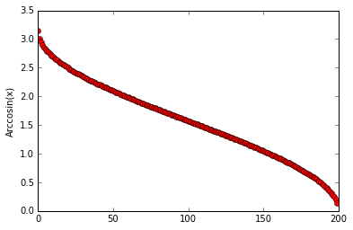

```python
import matplotlib.pyplot as plt
x = []
for i in range(-100,100,1):
    x += [i/100]
y = []
for i in range(len(x)):
    y += [math.acos(x[i])]
plt.plot(y,'ro')
plt.ylabel('Arccosin(x)')
plt.show()
```

[figure not shown]

```python
import matplotlib.pyplot as plt
x = []
for i in range(-100,100,1):
    x += [i/100]
y = []
for i in range(len(x)):
    y += [math.asin(x[i])]
plt.plot(y,'ro')
plt.ylabel('Arcsine(x)')
plt.show()
```

[figure not shown]

```python
import matplotlib.pyplot as plt
x = []
for i in range(-100,100,1):
    x += [i/100]
y = []
for i in range(len(x)):
    y += [math.atan(x[i])]
plt.plot(y,'ro')
plt.ylabel('Arctangent(x)')
plt.show()
```

[figure not shown]

```python
import matplotlib.pyplot as plt
x = []
for i in range(-100,100,1):
    x += [i/100]
y = []
for i in range(len(x)):
    y += [math.cos(x[i])]
plt.plot(y,'ro')
plt.ylabel('Cosine(x)')
plt.show()
```

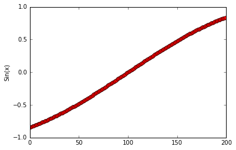

```python
import matplotlib.pyplot as plt
x = []
for i in range(-100,100,1):
    x += [i/100]
y = []
for i in range(len(x)):
    y += [math.sin(x[i])]
plt.plot(y,'ro')
plt.ylabel('Sin(x)')
plt.show()
```

[figure not shown]

```python
import matplotlib.pyplot as plt
x = []
for i in range(-100,100,1):
    x += [i/100]
y = []
for i in range(len(x)):
    y += [math.tan(x[i])]
plt.plot(y,'ro')
plt.ylabel('Tangent(x)')
plt.show()
```

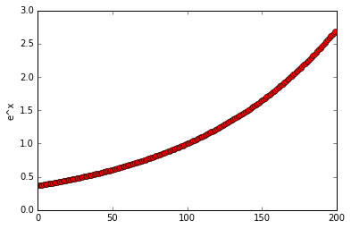

```python
import matplotlib.pyplot as plt
x = []
for i in range(-100,100,1):
    x += [i/100]
y = []
for i in range(len(x)):
    y += [math.exp(x[i])]
plt.plot(y,'ro')
plt.ylabel('e^x')
plt.show()
```

[figure not shown]

```python
import matplotlib.pyplot as plt
x = []
for i in range(1,100,1):
    x += [i/100]
y = []
for i in range(len(x)):
    y += [math.log(x[i])]
plt.plot(y,'ro')
plt.ylabel('Log(x)')
plt.show()

#Undefined at zero!!!
```

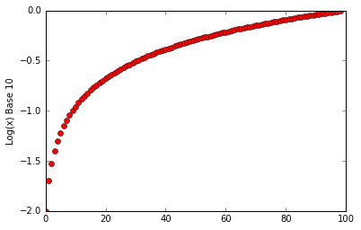

```python
import matplotlib.pyplot as plt
x = []
for i in range(1,100,1):
    x += [i/100]
y = []
for i in range(len(x)):
    y += [math.log10(x[i])]
plt.plot(y,'ro')
plt.ylabel('Log(x) Base 10')
plt.show()

#Undefined at zero!!!
```

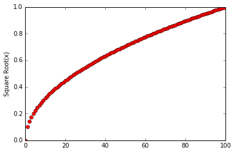

```python
import matplotlib.pyplot as plt
x = []
for i in range(0,100,1):
    x += [i/100]
y = []
for i in range(len(x)):
    y += [math.sqrt(x[i])]
plt.plot(y,'ro')
plt.ylabel('Square Root(x)')
plt.show()
```

## Chapter 6

### Files

##### Definitions

Writing to: Saving data to a file.

Reading from: The process of retrieving data from a file.

Input File: A file from which data is read.

Output File: A file that data is written to.

Text File: Contains data that has been encoded as text.

Structured as a sequence of lines.

Each line is terminated by and EOL (End Of Line).

Binary File: Contains data that has not been converted to text.

Binary files can only be processed by an application that knows about the files structure.

Sequential Access: File read sequentially from beginning to end, can't skip ahead.

Direct Access: Can jump directly to any piece of data in the file.

Must know where the record starts and ends.

Filename Extensions: Short sequences of characters that appear at the end of a filename preceded by a period.

Extension indicates type of data that is stored in the file.

File Object: Object associated with a specific file.

Provides a way for a program to work with the file; file object referenced by a variable.

Open Function: Used to open a file.

Creates a file object and associates it with a file on the disk.

Mode: A string specifying how the file will be opened.

Mode argument is optional; 'r' will be assumed.

'r': file will only be read.

'w': file opened for writing (an existing file with the same name will be erased).

'a': file opened to append.

'r+': file opened for both reading and writing.

File Locations: File paths should be "escaped" using backslashes.

Read Method: File object method reads entire file contents into memory.

Only works if file has been opened for reading.

Contents returned as a string.

Readline Method: File object method that reads a line from the file.

Line returned as a string, including '\n'.

Read Position: Marks the location of the next item to be read from a file.

Method: A function that belongs to an object.

Performs operations using that object.

Write Method: Used to write data to a file.

Close Method: Used to close a file.

Rstrip Method: Used to strip a character from a line read from a file.

Record: Set of data that describes one item.

Field: Single piece of data within a record.

##### Examples

```python
#Import remove to remove file after we are done with it.
from os import remove

#Create file
myNewFile = open("test.txt", "w")

#close file
myNewFile.close()

#Write to file
myNewFile = open("test.txt", "a")
myNewFile.write("Test")
myNewFile.close()

#Read from file
myNewFile = open("test.txt", "r")
for line in myNewFile:
    print(line)

myNewFile.close()

myFile = open("test.txt", "r")
fileString = myFile.read()
print(fileString)

myNewFile.close()

#rstrip()
myNewFile = open("test.txt", "r")
for line in myNewFile:
    print(line.rstrip("t"))

myNewFile.close()
remove("test.txt")
```

```
Test
Test
Tes
```

### Exceptions

##### Definitions

Exception: Error that occurs while a program is running.

Usually causes the program to halt.

Traceback: Error message that gives information regarding line numbers that caused the exception.

Indicates the type of exception and a brief description of the error that caused the exception to be raised.

Exception Handler: Code that responds when exceptions are raised and prevents a program from crashing.

Try Suite: Statements that can potentially raise an exception.

Handler: Statements contained in the except block.

Else Suite: Statements that execute after statements in the try suite if no exceptions are raised.

Finally Suite: Block of statements that execute after the finally clause (execute whether an exception occurs or not).

##### Examples

```python
#Catch Value Error

try:
    myInteger = int(input("Please enter an int:"))
    print(myInteger)
except ValueError:
    print("Error, that is not an integer.")
```

```
Please enter an int:asdf
Error, that is not an integer.
```

```python
#Catch IO Error

try:
    myFile = open("test.txt", "r")
except IOError:
    print("Error, file does not exist.")
```

```
Error, file does not exist.
```

```python
#Try / Except / Finally

try:
    myFile = open("test.txt", "r")
except IOError:
    print("Error, file does not exist.")
finally:
    myFile.close()
```

```
Error, file does not exist.
```